# caria_stefano_11_82_204

# Report tecnico progetto Esame Analisi dei Big Data

Il seguente progetto riguarda l’analisi un dataset di biglietti aerei venduti online da una compagnia aerea che effettua collegamenti dalle principali città italiane alle principali città europee.

# Analisi

Il presente progetto contiene i seguenti punti:

# Analisi descrittiva del dataset:

- 1. Descrizione dei dati osservati (indici statistici univariati e/o bivariati, rappresentazioni grafiche, ecc.);
- 2. Segmentazione della clientela sulla base delle variabili osservate;
- 3. Suddivisione casuale del dataset in campione di apprendimento (2/3 · n) e campione test (1/3 · n). Stima, sul campione di apprendimento, di 3 modelli (Lasso, PCR, PLS ) in funzione della variabile “Cfidelity” (-> factor, levels:alta, bassa. Creata tramite ricodifica della Variabile “Fidelity”).

# Importazione del dataset

```r
load("~/Documents/r Wdirectory/Dati_Caria.RData")
summary(dati)
```

```
      Data             Unit_Ticket     Seat       PriorBoard  Luggage
 Min.   :2010-01-01   Min.   : 87.9   No :11765   No :11576   No :13111
 1st Qu.:2012-06-21   1st Qu.:158.0   Yes:12233   Yes:12422   Yes:10887
 Median :2014-12-27   Median :173.8
 Mean   :2014-12-28   Mean   :175.3
 3rd Qu.:2017-06-30   3rd Qu.:191.5
 Max.   :2019-12-31   Max.   :274.6
 Return         Fidelity         BookTime         Taxes          Discount
 No :12897   Min.   :  0.00   Min.   : 3.00   Min.   : 8.88   Min.   : 0.000
 Yes:11101   1st Qu.: 33.35   1st Qu.: 9.00   1st Qu.:20.23   1st Qu.: 0.860
             Median : 43.06   Median :11.00   Median :23.33   Median : 1.940
             Mean   : 45.31   Mean   :11.76   Mean   :23.68   Mean   : 3.493
             3rd Qu.: 56.29   3rd Qu.:15.00   3rd Qu.:27.00   3rd Qu.: 6.210
             Max.   :100.00   Max.   :22.00   Max.   :41.32   Max.   :15.160
      NPax          Departure         Arrival            ModPag
 Min.   : 1.000   Milan  :5481   London   :11212   C_debito : 3095
 1st Qu.: 4.000   Rome   :9858   Paris    :  192   C_credito:20903
 Median : 6.000   Naples : 380   Madrid   : 2938
 Mean   : 5.726   Palermo:2806   Amsterdam: 9656
 3rd Qu.: 7.000   Bergamo:1656
 Max.   :12.000   Venice :3817
   NBookMonth     NAccWebWeek    NComplaintsYear  NRefundYear      NCancelYear
 Min.   :0.000   Min.   :0.000   Min.   :0.000   Min.   : 0.000   Min.   : 1.00
 1st Qu.:3.000   1st Qu.:2.000   1st Qu.:1.000   1st Qu.: 0.000   1st Qu.: 4.00
 Median :4.000   Median :3.000   Median :1.000   Median : 0.000   Median : 5.00
 Mean   :3.993   Mean   :2.996   Mean   :1.157   Mean   : 5.853   Mean   : 5.01
 3rd Qu.:5.000   3rd Qu.:4.000   3rd Qu.:2.000   3rd Qu.: 0.000   3rd Qu.: 6.00
 Max.   :9.000   Max.   :7.000   Max.   :6.000   Max.   :65.000   Max.   :10.00
```

```r
str(dati)
```

```
'data.frame':   23998 obs. of  19 variables:
 $ Data           : Date, format: "2010-01-01" "2010-01-01" ...
 $ Unit_Ticket    : num  174 160 173 189 152 ...
 $ Seat           : Factor w/ 2 levels "No","Yes": 2 1 2 2 1 1 2 1 1 2 ...
 $ PriorBoard     : Factor w/ 2 levels "No","Yes": 2 2 1 1 2 1 2 2 2 1 ...
 $ Luggage        : Factor w/ 2 levels "No","Yes": 2 1 1 1 2 1 1 2 2 2 ...
 $ Return         : Factor w/ 2 levels "No","Yes": 1 1 2 1 2 1 1 1 1 1 ...
 $ Fidelity       : num  53.5 47.9 39 40.9 30.1 ...
 $ BookTime       : num  18 12 10 14 13 15 14 18 18 16 ...
 $ Taxes          : num  24.6 24.5 18.7 19.6 14.9 ...
 $ Discount       : num  6.97 1.23 0.7 1.01 0.48 1.33 1.06 9.91 8.97 8.02 ...
 $ NPax           : num  4 6 4 9 4 5 5 6 7 7 ...
 $ Departure      : Factor w/ 6 levels "Milan","Rome",..: 2 2 1 6 2 2 2 2 5 4 ...
 $ Arrival        : Factor w/ 4 levels "London","Paris",..: 1 1 4 1 1 1 1 1 1 1 ...
 $ ModPag         : Factor w/ 2 levels "C_debito","C_credito": 2 2 2 2 2 2 2 1 2 2 ...
 $ NBookMonth     : num  5 4 3 5 5 4 5 4 4 4 ...
 $ NAccWebWeek    : num  3 3 3 5 3 2 4 3 2 3 ...
 $ NComplaintsYear: num  1 0 2 3 1 1 2 0 0 1 ...
 $ NRefundYear    : num  0 0 27 0 0 0 28 0 14 0 ...
 $ NCancelYear    : num  3 4 6 6 4 4 5 5 4 5 ...
```

```r
sum(is.na(dati)) #non sono presenti valori mancanti
```

```
[1] 0
```

Per prima cosa, è stato importato il dataset. Dal summary si può osservare che non sono presenti valori mancanti. Dalla funzione str() si osserva che ci sono 11 variabili num e 7 factor.

# Analisi esplorativa del dataset: grafici

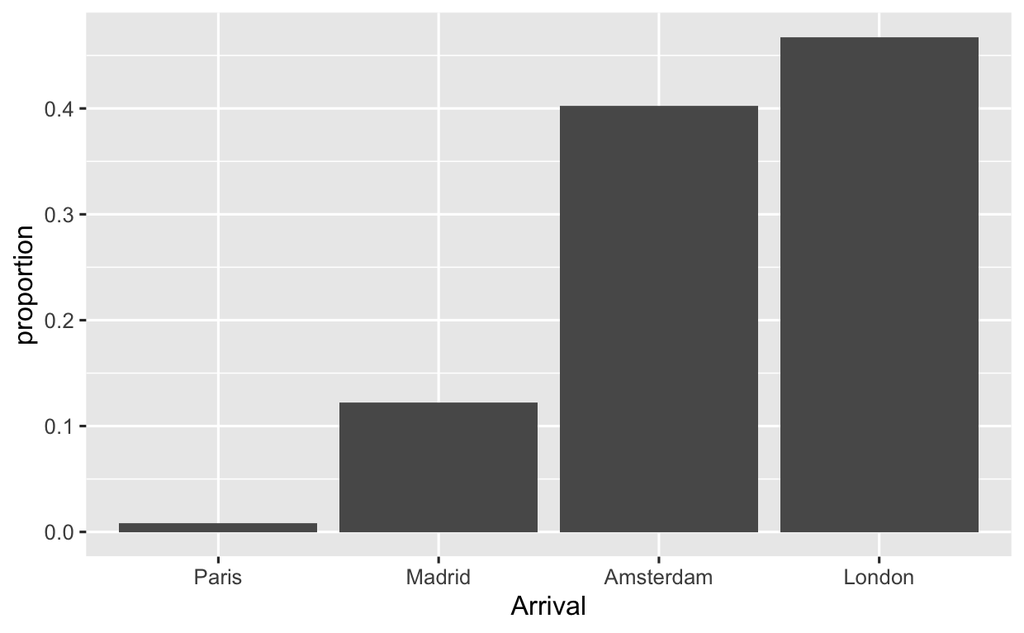

```r
library("tidyverse")

#1
tab <-dati %>%
  count(Arrival) %>%
  mutate(proportion= n/sum(n)) %>%
  mutate(Arrival= reorder(Arrival, proportion))

tab %>%
  ggplot(aes(Arrival, proportion))+
  geom_bar(stat = "identity")
```

La proporzione di biglietti venduti per le 4 diverse destinazioni

```r
tab2 <-dati2 %>%
  count(Departure) %>%
  mutate(proportion= n/sum(n)) %>%
  mutate(Departure= reorder(Departure, proportion))
```

[output not shown]

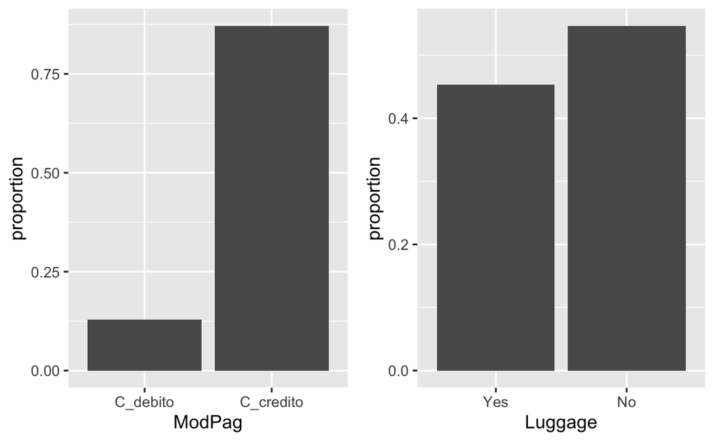

```r
tab3 <- dati %>%
  count(ModPag) %>%
  mutate(proportion= n/sum(n)) %>%
  mutate(ModPag = reorder(ModPag, proportion))

tab3<-tab3 %>%
  ggplot(aes(ModPag, proportion))+
  geom_bar(stat = "identity") # quasi il 90% (0.87) dei clienti ha utilizzato
#la carta di credito per il pagamento

#4
tab4 <- dati %>%
  count(Luggage) %>%
  mutate(proportion= n/sum(n)) %>%
  mutate(Luggage = reorder(Luggage, proportion))

tab4<- tab4 %>%
  ggplot(aes(Luggage, proportion))+
  geom_bar(stat = "identity") # il 54% dei clienti ha effettuato una
#prenotazione senza imbarcare un bagaglio aggiuntivo
grid.arrange(tab3, tab4, ncol=2)
```

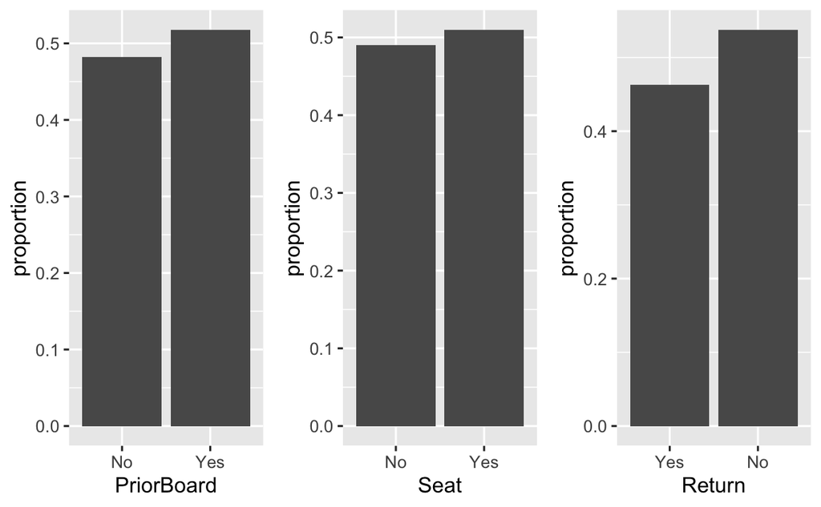

```r
#5
tab5 <- dati %>%
  count(PriorBoard) %>%
  mutate(proportion= n/sum(n)) %>%
  mutate(PriorBoard = reorder(PriorBoard, proportion))

tab5<- tab5 %>%
  ggplot(aes(PriorBoard, proportion))+
  geom_bar(stat = "identity") # il 52% (0.517) dei clienti ha effettuato una
#prenotazione con imbarco prioritario

#6
tab6 <- dati %>%
  count(Seat) %>%
  mutate(proportion= n/sum(n)) %>%
  mutate(Seat = reorder(Seat, proportion))

tab6<- tab6 %>%
  ggplot(aes(Seat, proportion))+
  geom_bar(stat = "identity") # il 51% (0.509) dei clienti ha effettuato una
#prenotazione del posto a sedere



#7
tab7 <- dati %>%
  count(Return) %>%
  mutate(proportion= n/sum(n)) %>%
  mutate(Return = reorder(Return, proportion))

tab7<-tab7 %>%
  ggplot(aes(Return, proportion))+
  geom_bar(stat = "identity") # il 54% (0.537) dei clienti ha effettuato una
#prenotazione solo andata
grid.arrange(tab5, tab6, tab7, ncol=3)
```

```r
NA
NA
NA
NA
```

Il primo grafico a sinistra mostra che il 52% (0.517) dei clienti ha effettuato una prenotazione con imbarco prioritario. Dal secondo grafico si osserva che il 51% (0.509) dei clienti ha effettuato una prenotazione del posto a sedere. Dal terzo grafico invece, si osserva che il 54% (0.537) dei clienti ha effettuato una prenotazione solo andata.

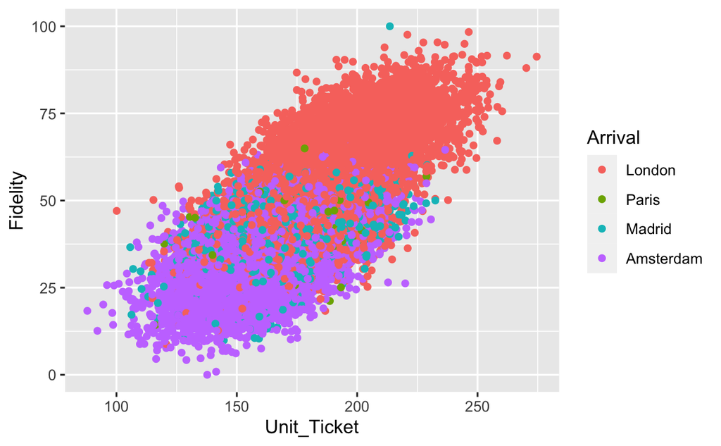

```r
filter(dati) %>%
  ggplot(aes(Unit_Ticket, Fidelity, color= Arrival)) +
  geom_point()
```

Il prezzo dei biglietti di Londra è più alto rispetto a quello di Amsterdam e Madrid. Il costo inferiore sembra essere dovuto al fatto che l’indice di fidelizzazione del cliente è basso per quest’ultime, mentre assume valori alti per Londra.

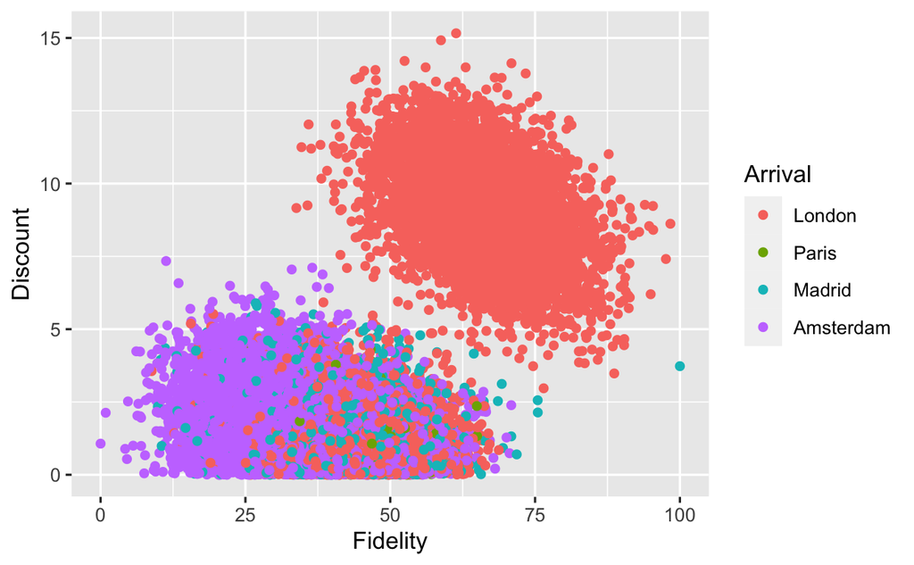

```r
filter(dati) %>%
  ggplot(aes(Fidelity, Discount, color= Arrival)) +
  geom_point()
```

```r
NA
NA
```

I clienti che acquistano i biglietti per Londra risultano essere più fedeli rispetto a quelli di Amsterdam e Madrid e per questo godono di uno sconto maggiore a dispetto di quest’ultimi

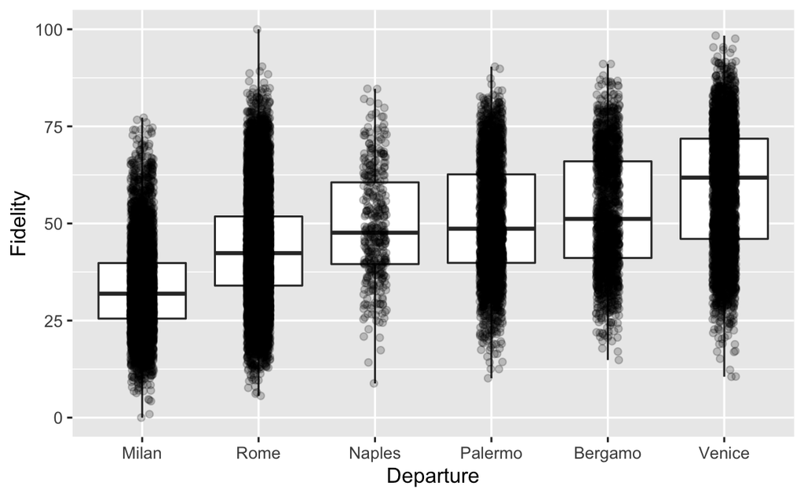

```r
dati  %>%
  ggplot(aes( y=Fidelity, Departure)) +
  geom_boxplot(coef=3) +
  geom_jitter(width= 0.1, alpha =0.2)
```

```r
NA
```

l’indice di fedeltà risulta essere mediamente più alto per le prenotazioni con partenza da Venezia

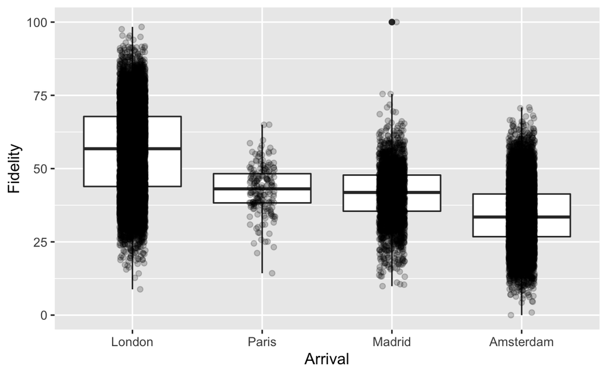

```r
dati  %>%
  ggplot(aes( y=Fidelity, Arrival)) +
  geom_boxplot(coef=3) +
  geom_jitter(width= 0.1, alpha =0.2)
```

```r
NA
NA
```

Per quanto riguarda l’areoporto di Arrivo, l’indice di fedeltà risulta essere mediamente più alto per le prenotazioni con arrivo a Londra

```r
library("lubridate")
dates<-ymd(dati$Data)


month_day_year<-tibble(date = dates,
                       month = month(dates, label = TRUE),
                       day = day(dates),
                       year = year(dates))


head(month_day_year)
```

| date | month | day | year |
| --- | --- | --- | --- |
| 2010-01-01 | Gen | 1 | 2010 |
| 2010-01-01 | Gen | 1 | 2010 |
| 2010-01-01 | Gen | 1 | 2010 |
| 2010-01-01 | Gen | 1 | 2010 |
| 2010-01-01 | Gen | 1 | 2010 |
| 2010-01-01 | Gen | 1 | 2010 |

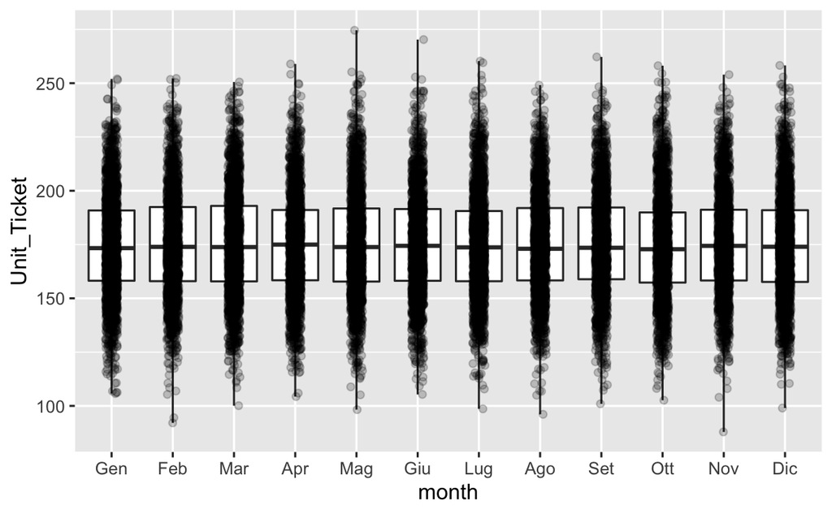

```r
#11  graf
dati2= dati
dati2<- mutate(dati2, month= month_day_year$month ) #inserisco una nuova colonna
dati2  %>%
  ggplot(aes(month, Unit_Ticket)) +
  geom_boxplot(coef=3) +
  geom_jitter(width= 0.1, alpha =0.2)
```

```r
#le distribuzioni del prezzo del biglietto nel corso dell'anno è molto simile. Il prezzo del biglietto più basso si è registrato a Novembre, il più prezzo più alto è stato registato a maggio, quello più basso a novembre.
```

Dopo aver creato un oggetto tibble per dividere giorno, mese e anno, inserisco una nuova colonna in una copia del dataset (dati2). tramite ggplot, ottengodei boxplot riguardanti le distribuzioni del prezzo del biglietto nel corso dell’anno. tali distribuzioni risultano essere molto simile. Il prezzo del biglietto più basso si è registrato a Novembre, il più prezzo più alto è stato registato a maggio.

```r
#ricodifica dell'indice di fedeltà
dati2$clientFidelity[dati2$Fidelity<=50] = "basso"
dati2$clientFidelity[dati2$Fidelity>50] = "alto"

fedeltà <-as.factor(dati2$clientFidelity)
class(fedeltà)
```

```
[1] "factor"
```

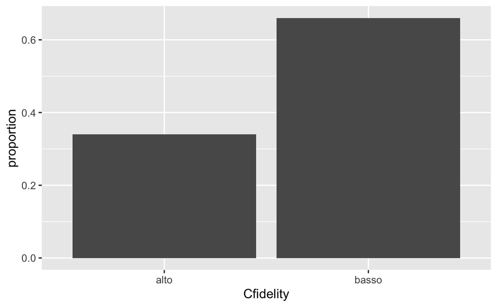

```r
dati2<- dati2 %>% mutate(Cfidelity= fedeltà)

#eliminazione colonne rindondanti dopo la ricodifica
dati2= dati2[-21] #elimino ClientFidelity
dati2= dati2[-7] #elimino la vecchia colonna Fidelity
dati2= dati2[-19]



#12
tab12 <- dati2 %>%
  count(Cfidelity) %>%
  mutate(proportion= n/sum(n)) %>%
  mutate(Cfidelity = reorder(Cfidelity, proportion))

tab12 %>%
  ggplot(aes(Cfidelity, proportion))+
  geom_bar(stat = "identity") # il 66% (0.659) dei clienti ha un
```

```r
#indice di fidelizzazione (da 0 a 100)  basso  (minore al 50) mentre il 34 %
#dei clienti ha un valore alto per questo indice (maggiore di 50)
```

é stato ricodificato l’indice di fedelizzazione: è stata creata una nuova variabile Cfidelity) in cui se l’indice di fidelizzazione (tra 0 e 100) è maggiore di 50 verrà assegnato il valore “alto”, se invece sarà minore di 50 “basso”. Il 66% (0.659) dei clienti ha un indice di fidelizzazione basso (minore al 50) mentre il 34 % dei clienti ha un valore alto per questo indice (maggiore di 50)

```r
library(dslabs)


arrival_departures <- count(dati, Departure, Arrival) #creo un nuovo oggetto
#tibble in cui conto i viaggi in base a aereoporto di partenza e aereoporto
#di arrivo

arrival_departures
```

| Departure | Arrival | n |
| --- | --- | --- |
| Milan | London | 1022 |
| Milan | Paris | 32 |
| Milan | Madrid | 490 |
| Milan | Amsterdam | 3937 |
| Rome | London | 4448 |
| Rome | Paris | 89 |
| Rome | Madrid | 1432 |
| Rome | Amsterdam | 3889 |
| Naples | London | 229 |
| Naples | Paris | 2 |

[output cut: 14 more lines]

```r
summary(arrival_departures)
```

```
   Departure      Arrival        n
 Milan  :4   London   :6   Min.   :   2.0
 Rome   :4   Paris    :6   1st Qu.:  81.0
 Naples :4   Madrid   :6   Median : 387.5
 Palermo:4   Amsterdam:6   Mean   : 999.9
 Bergamo:4                 3rd Qu.:1150.8
 Venice :4                 Max.   :4448.0
```

```r
#13
p1<-arrival_departures %>% unite(flights, Departure, Arrival) #unisco le colonne
#Unite tramite la funzione Unite della libreria Tidyr
p1
```

| flights | n |
| --- | --- |
| Milan_London | 1022 |
| Milan_Paris | 32 |
| Milan_Madrid | 490 |
| Milan_Amsterdam | 3937 |
| Rome_London | 4448 |
| Rome_Paris | 89 |
| Rome_Madrid | 1432 |
| Rome_Amsterdam | 3889 |
| Naples_London | 229 |
| Naples_Paris | 2 |

[output cut: 14 more lines]

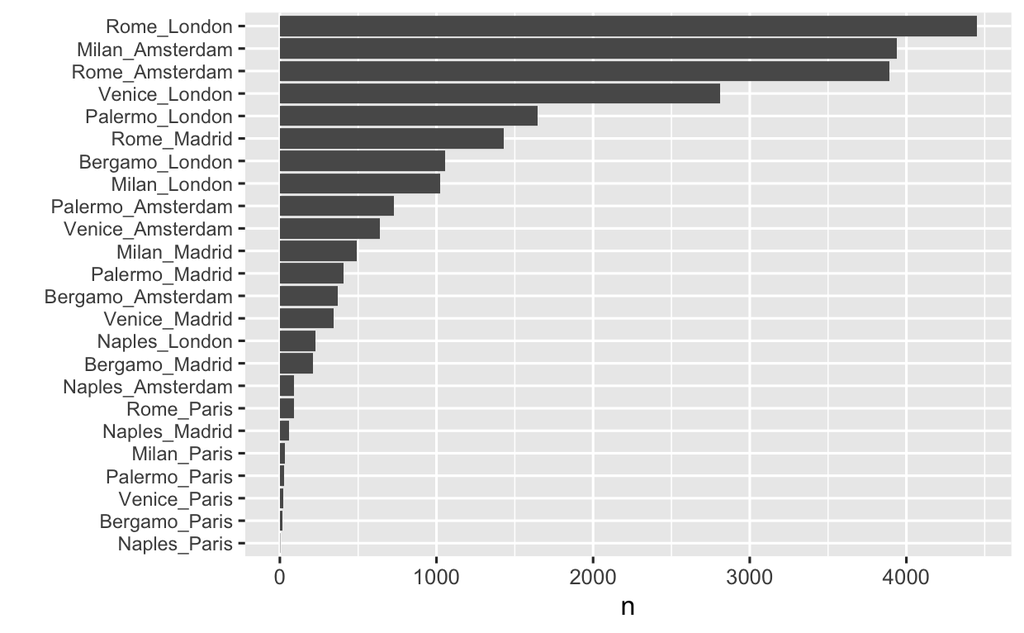

```r
p1 %>%
  mutate( flights= reorder(flights, n)) %>%
  ggplot(aes(flights, n)) +
  geom_bar(stat= "identity")+
  coord_flip()+
  theme(axis.text.y = element_text(size = 8)) +
  xlab("")
```

```r
#vediamo che i biglietti maggiormente venduti nel sito sono per il volo Roma-Londra, seguito da Milano-Amsterdam e Roma-Amsterdam
```

Si osserva che i biglietti maggiormente venduti nel sito sono per il volo Roma-Londra, seguito da Milano-Amsterdam e Roma-Amsterdam

```r
index<- dati2$Unit_Ticket; x<- dati2$Unit_Ticket[index]
m <-mean(x) ; s<- sd(x)
c(average=m, sd= s )
```

```
  average        sd
177.70689  25.81076
```

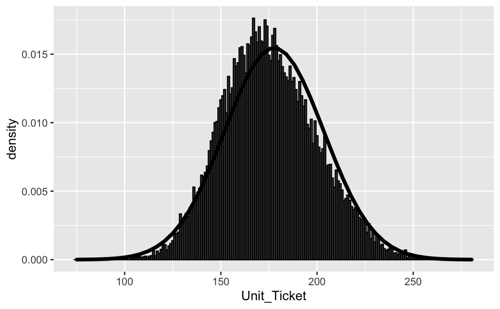

```r
norm_dist<- data.frame(x= seq(-4, 4, len=50)*s + m) %>%
  mutate(density= dnorm(x, m, s))

#14
dati2 %>% ggplot(aes(Unit_Ticket))+
  geom_histogram(aes(y=..density..), binwidth = 1, color = "black")+
  geom_line(aes(x, density), data= norm_dist, lwd=1.5)
```

```r
##La distribuzione del prezzo dei biglietti venduti sembra essere
#approssimabile a una normale
```

La distribuzione del prezzo dei biglietti venduti sembra essere approssimabile a una normale.

# PCA

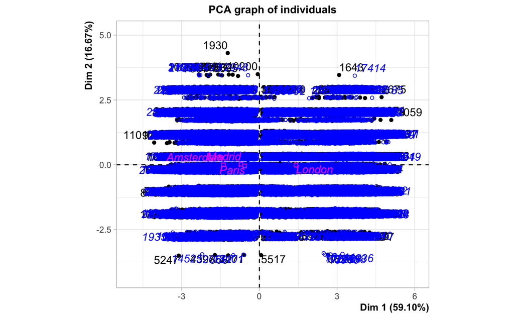

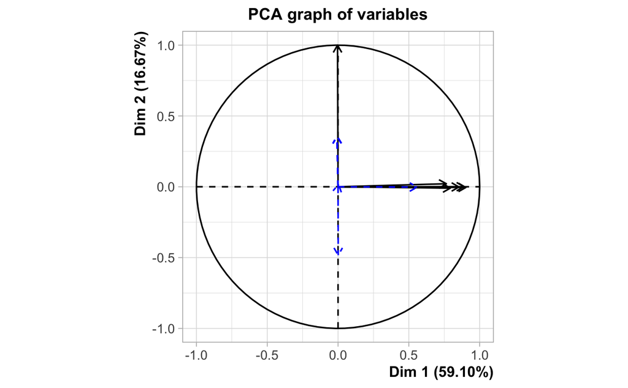

```r
library(FactoMineR)

attach(dati)
new_dati<- tibble(Unit_Ticket, Fidelity, BookTime, Taxes, Discount, NPax, NBookMonth,NAccWebWeek, NComplaintsYear, NRefundYear,NCancelYear, Seat, PriorBoard, Luggage, Return, Departure, Arrival, ModPag)

new_dati2 <- tibble(Unit_Ticket, Fidelity, BookTime, Taxes, Discount, NPax, NBookMonth,NAccWebWeek, NComplaintsYear, NRefundYear, NCancelYear, Arrival )
res <- PCA(new_dati2,
           scale.unit = TRUE,
           ind.sup = 12000: 23998,
           quanti.sup = 6:10,
           quali.sup = 12,
           ncp=8)
```

```r
NA
NA
NA
NA
```

```r
summary(res)
```

```
Call:
PCA(X = new_dati2, scale.unit = TRUE, ncp = 8, ind.sup = 12000:23998,
     quanti.sup = 6:10, quali.sup = 12)


Eigenvalues
                       Dim.1   Dim.2   Dim.3   Dim.4   Dim.5   Dim.6
Variance               3.546   1.000   0.585   0.470   0.229   0.169
% of var.             59.097  16.671   9.758   7.839   3.811   2.824
Cumulative % of var.  59.097  75.768  85.525  93.365  97.176 100.000

Individuals (the 10 first)
                    Dist    Dim.1    ctr   cos2    Dim.2    ctr   cos2    Dim.3    ctr   cos2
1               |  2.690 |  1.566  0.006  0.339 | -1.739  0.025  0.418 | -0.612  0.005  0.052 |
2               |  1.273 | -0.372  0.000  0.085 | -0.864  0.006  0.461 | -0.264  0.001  0.043 |
3               |  1.685 | -1.231  0.004  0.534 |  0.840  0.006  0.248 |  0.731  0.008  0.188 |
4               |  1.658 | -0.261  0.000  0.025 |  0.837  0.006  0.255 |  0.952  0.013  0.330 |
5               |  2.605 | -1.827  0.008  0.492 | -0.898  0.007  0.119 |  0.214  0.001  0.007 |
6               |  2.499 |  1.208  0.003  0.234 | -0.902  0.007  0.130 |  1.827  0.047  0.534 |
7               |  1.666 | -0.867  0.002  0.271 | -0.024  0.000  0.000 |  0.173  0.000  0.011 |
8               |  3.457 |  3.270  0.025  0.895 | -0.016  0.000  0.000 |  0.395  0.002  0.013 |
9               |  3.018 |  2.754  0.018  0.833 | -0.881  0.006  0.085 |  0.127  0.000  0.002 |
10              |  1.935 |  1.632  0.006  0.711 | -0.017  0.000  0.000 | -0.133  0.000  0.005 |

Supplementary individuals (the 10 first)
                    Dist    Dim.1   cos2    Dim.2   cos2    Dim.3   cos2
12000           |  1.403 | -0.515  0.135 |  0.006  0.000 | -0.310  0.049 |
12001           |  1.325 | -0.638  0.232 | -0.028  0.000 |  0.647  0.239 |
12002           |  0.913 | -0.207  0.051 | -0.014  0.000 |  0.331  0.131 |
12003           |  2.435 | -2.004  0.678 | -0.017  0.000 | -0.388  0.025 |
12004           |  2.964 |  2.523  0.725 |  0.891  0.090 | -1.105  0.139 |
12005           |  1.726 | -1.112  0.415 | -0.853  0.244 | -0.672  0.152 |
12006           |  1.462 | -0.825  0.318 |  0.847  0.336 |  0.441  0.091 |
12007           |  2.831 |  2.742  0.938 | -0.003  0.000 | -0.158  0.003 |
12008           |  2.336 | -1.759  0.567 | -0.898  0.148 |  0.698  0.089 |
12009           |  3.771 |  3.465  0.844 |  0.855  0.051 |  1.005  0.071 |

Variables
                   Dim.1    ctr   cos2    Dim.2    ctr   cos2    Dim.3    ctr   cos2
Unit_Ticket     |  0.793 17.726  0.629 | -0.010  0.009  0.000 |  0.544 50.632  0.296 |
Fidelity        |  0.902 22.948  0.814 | -0.005  0.002  0.000 |  0.223  8.479  0.050 |
BookTime        |  0.889 22.283  0.790 |  0.001  0.000  0.000 | -0.109  2.041  0.012 |
Taxes           |  0.765 16.490  0.585 |  0.022  0.047  0.000 | -0.382 24.968  0.146 |
Discount        |  0.854 20.553  0.729 | -0.001  0.000  0.000 | -0.285 13.845  0.081 |
NCancelYear     | -0.004  0.000  0.000 |  1.000 99.942  1.000 |  0.014  0.034  0.000 |

Supplementary continuous variables
                   Dim.1   cos2    Dim.2   cos2    Dim.3   cos2
NPax            |  0.558  0.311 | -0.002  0.000 |  0.198  0.039 |
NBookMonth      |  0.001  0.000 | -0.483  0.233 | -0.018  0.000 |
NAccWebWeek     | -0.006  0.000 |  0.358  0.128 |  0.004  0.000 |
NComplaintsYear | -0.009  0.000 |  0.357  0.128 |  0.001  0.000 |
NRefundYear     |  0.003  0.000 |  0.017  0.000 |  0.007  0.000 |

Supplementary categories
                     Dist     Dim.1    cos2  v.test     Dim.2    cos2  v.test     Dim.3    cos2  v.test
London          |   1.429 |   1.409   0.973  76.366 |  -0.008   0.000  -0.846 |  -0.027   0.000  -3.548 |
Paris           |   0.730 |  -0.567   0.605  -2.949 |  -0.038   0.003  -0.376 |   0.302   0.171   3.864 |
Madrid          |   0.796 |  -0.715   0.807 -15.489 |   0.025   0.001   1.022 |   0.246   0.096  13.140 |
Amsterdam       |   1.421 |  -1.388   0.954 -66.715 |   0.003   0.000   0.247 |  -0.049   0.001  -5.850 |
```

La PCA può essere utile per la segmentazione della clientela. Si osserva che il primo asse fattoriale è correlato positivamente con le variabili : Unit_Tickets, Fidelity, BookTime, Taxes, Discount. Il secondo asse fattoriale è correlato positivamente con NCancelYear. inoltre sono state proiettate le variabili illustrative.

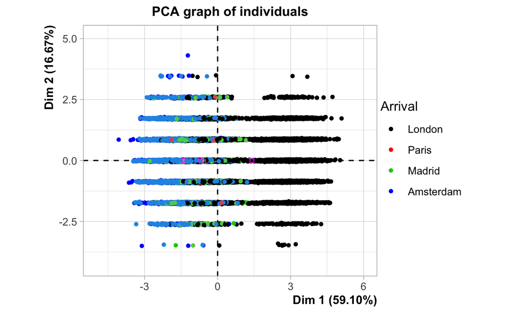

```r
plot(res, cex=0.8, habillage="Arrival", label = "none")
```

Si osserva che i punti che i punti sul primo quadrante riguardano la tipologia di clienti con un alto indice di fidelizzazione per le quali prenotazioni si caratterizzano per il costo del biglietto elevato, per uno sconto alto sulla prenotazione, e per un alto numero di giorni di anticipo sulla prenotazione rispetto alla partenza.

# Suddivisione casuale del dataset in training set e test set

```r
set.seed(123)
x=model.matrix(Cfidelity ~.,dati2)[,-1]

train = sample(nrow(x), nrow(x)*2/3)
test=(-train)
dati_test = dati2[-train, ] #creo il test set
dati_train = dati2[train,]

y=as.numeric(dati2$Cfidelity)
y.test=as.numeric(y[test])
```

Il dataset è stato diviso casualmente per 2/3 in train e per 1/3 test set

#lasso

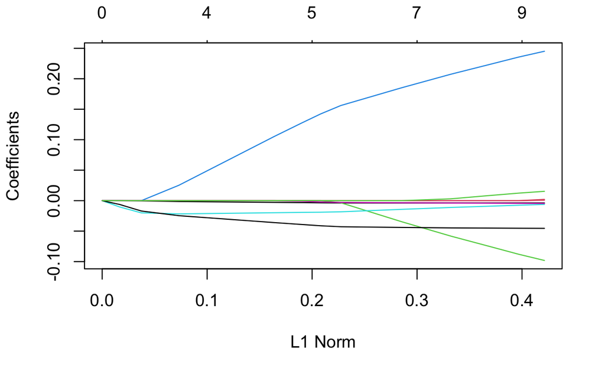

```r
library(glmnet)
grid=10^seq(10,-2,length=100)
lasso.mod=glmnet(x[train ,],as.numeric(y[train]),alpha=1,lambda=grid)
plot(lasso.mod)
```

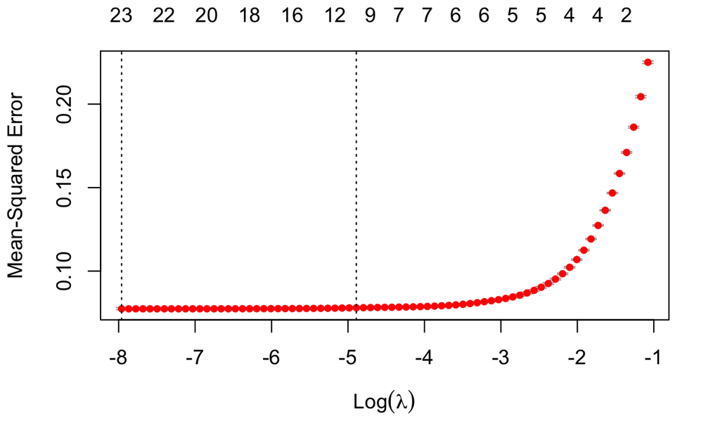

```r
cv.out= cv.glmnet(x[train ,],as.numeric(y[train]),alpha=1)
plot(cv.out)
```

```r
bestlam=cv.out$lambda.min
lasso.pred=predict(lasso.mod,s=bestlam ,newx=x[test,])
table(y.test, round(lasso.pred,0)) #777 malclassificati su 8000 --> 0.0971 -->9,7%
```

```
y.test    1    2
     1 1984  702
     2   76 5238
```

778 malclassificati su 8000 –> 0.0971 –>9,7%

```r
out=glmnet(x,y,alpha=1,lambda=grid)
lasso.coef=predict(out,type="coefficients",s=bestlam)[1:19,]
lasso.coef
```

```
     (Intercept)             Data      Unit_Ticket          SeatYes    PriorBoardYes       LuggageYes        ReturnYes
     2.573904903      0.000000000     -0.003758809      0.001333084      0.000000000     -0.100771968      0.246232407
        BookTime            Taxes         Discount             NPax    DepartureRome  DepartureNaples DeparturePalermo
    -0.006281931     -0.004634191     -0.044389692      0.000000000      0.000000000      0.000000000      0.000000000
DepartureBergamo  DepartureVenice     ArrivalParis    ArrivalMadrid ArrivalAmsterdam
     0.000000000      0.000000000      0.000000000      0.010621467      0.000000000
```

```r
lasso.coef[lasso.coef!=0]
```

```
  (Intercept)   Unit_Ticket       SeatYes    LuggageYes     ReturnYes      BookTime         Taxes      Discount ArrivalMadrid
  2.573904903  -0.003758809   0.001333084  -0.100771968   0.246232407  -0.006281931  -0.004634191  -0.044389692   0.010621467
```

solamente 8 dei coefficenti stimati hanno valore diverso da 0. Per cui il lasso model scelto dalla cross-validation coniene solo 8 variabili

```r
summary(lasso.mod)
```

```
          Length Class     Mode
a0         100   -none-    numeric
beta      2400   dgCMatrix S4
df         100   -none-    numeric
dim          2   -none-    numeric
lambda     100   -none-    numeric
dev.ratio  100   -none-    numeric
nulldev      1   -none-    numeric
npasses      1   -none-    numeric
jerr         1   -none-    numeric
offset       1   -none-    logical
call         5   -none-    call
nobs         1   -none-    numeric
```

#PCR

```r
pcr_model <- pcr(as.numeric(Cfidelity) ~ ., data = dati2,
                 scale = TRUE,
                 validation = "CV")

summary(pcr_model)
```

```
Data:   X dimension: 23998 24
    Y dimension: 23998 1
Fit method: svdpc
Number of components considered: 24

VALIDATION: RMSEP
Cross-validated using 10 random segments.
       (Intercept)  1 comps  2 comps  3 comps  4 comps  5 comps  6 comps  7 comps  8 comps  9 comps  10 comps  11 comps
CV          0.4738   0.3038   0.3038   0.3038   0.3038   0.2962   0.2956   0.2925   0.2924   0.2921    0.2921    0.2919
adjCV       0.4738   0.3038   0.3038   0.3038   0.3038   0.2962   0.2957   0.2925   0.2924   0.2921    0.2921    0.2919
       12 comps  13 comps  14 comps  15 comps  16 comps  17 comps  18 comps  19 comps  20 comps  21 comps  22 comps  23 comps
CV       0.2918    0.2916    0.2917    0.2917    0.2917    0.2913    0.2868    0.2867     0.281    0.2801    0.2801    0.2793
adjCV    0.2916    0.2916    0.2916    0.2917    0.2917    0.2913    0.2867    0.2867     0.281    0.2801    0.2801    0.2793
       24 comps
CV       0.2793
adjCV    0.2793

TRAINING: % variance explained
                       1 comps  2 comps  3 comps  4 comps  5 comps  6 comps  7 comps  8 comps  9 comps  10 comps  11 comps
X                        22.04    28.77    35.01    40.94    46.53    51.43    56.24    60.79    65.09     69.34     73.55
as.numeric(Cfidelity)    58.90    58.90    58.91    58.92    60.96    61.08    61.91    61.95    62.03     62.03     62.10
                       12 comps  13 comps  14 comps  15 comps  16 comps  17 comps  18 comps  19 comps  20 comps  21 comps
X                         77.69     81.82     85.38     88.70     91.69     94.06     95.85     97.45     98.55     99.15
as.numeric(Cfidelity)     62.16     62.17     62.17     62.17     62.17     62.26     63.45     63.46     64.90     65.13
                       22 comps  23 comps  24 comps
X                         99.56     99.81    100.00
as.numeric(Cfidelity)     65.13     65.34     65.34
```